# Kenya Soil Health Study

Yield Paired Round 1

Matt Lowes

August 07, 2017

# 1 Objectives

# 2 Key Takeaways

> None for the time being

TODO - check projection from baseline maps, are they shifted over? TODO - how to connect photos to farmers for enumerators

# 3 Data Prep

```r
dataDir <- normalizePath(file.path("..", "..", "data"))
soilDir <- normalizePath(file.path("..", "..", "OAF Soil Lab Folder", "Projects", "ke_shs_maize_paired"))
forceUpdateAll <- FALSE
source("../oaflib/commcareExport.R")
```

How do soil attributes predict yields (climbing beans) >> can we understand yield as functions of carbon, pH, etc. Are the curves as we might expect?

## 3.1 Load soil sampling data

`py` is the associated survey data with the soil data. We’ll use it to help merge the soil data with the yield data

```r
py <- getFormData("harvest", "Harvest Soil Sampling 2016", "Soil Sampling 2016", forceUpdate = forceUpdateAll)
```

```
[1] "found f6af21e494f93ab7c81b7d664632b9e"
```

```r
#write.csv(py, file="rawCcYpData.csv", row.names=F)
```

## 3.2 Load soil

It’s probably safe to assume that if there isn’t a soil code the data can be dropped. It’s not clear how to match the yield data to the soil data. There might be a way to use the client id from the SHS data but I also don’t know if that maps to the M&E data. I could try it if Nathaniel doesn’t have a suggestion.

```r
#names(bean)[grep("soil",names(bean))]
#names(bean)[grep("id",names(bean))]
#table(bean$soil_code, useNA = 'ifany')
pairedSoilDir <- normalizePath(file.path("..", "..", "OAF Soil Lab Folder", "Projects", "ke_shs_maize_paired", "4_predicted", "other_summaries"))
pairedSoil <- read.csv(file=paste(pairedSoilDir, "combined-predictions-including-bad-ones.csv", sep = "/"))
pSoilIdDir <- normalizePath(file.path("..", "..", "OAF Soil Lab Folder", "Projects", "ke_shs_maize_paired", "5_merged"))
pSoilIds <- read_excel(paste(pSoilIdDir, "database.xlsx", sep = "/"))
```

## 3.3 Load yield data

```r
yd <- getFormData("harvest", "Harvest Survey 2016", "Maize Dry Weight", forceUpdate = forceUpdateAll)
```

```
[1] "found 261b1bc7fc4d9f22b439ec63b47b363"
```

```r
dat <- yd %>%
  setNames(tolower(names(.))) %>%
  dplyr::select(contains("bag"), contains("cmid"), contains("oafid")) %>%
  rename(
    separate = `did the farmer keep maize separate in bags ?`,
    added = `was anything added or removed from the harvest bag?`,
    bagA.oaf = `oaf farmer, oaf plot dry weight bag a`,
    bagB.oaf = `oaf farmer, oaf plot dry weight bag b`,
    bagA.nonoaf = `oaf farmer, non oaf plot dry weight bag a`,
    bagB.nonoaf = `oaf farmer, non oaf plot dry weight bag b`,
    bagA.control = `non oaf farmer dry weight bag a`,
    bagB.control = `non oaf farmer dry weight bag b`,
    cmid = `#form/identifier/cmid`,
    oafid = `#form/identifier/oafid`
  ) %>%
  gather(key, value, -c(cmid, oafid, separate, added)) %>%
  separate(key, c("var", "type"), sep="\\.") %>%
  filter(!is.na(value)) %>%
  mutate(value = ifelse(value<0, NA, value)) %>%
  group_by(cmid, type) %>%
  summarize(bagYield = sum(value, na.r=T)) %>%
  arrange(cmid)
harvestBox <- getFormData("harvest", "Harvest Survey 2016", "Maize Harvest Box", forceUpdate = forceUpdateAll)
```

```
[1] "found 84c14926836f446b6a25695848bd183"
```

```r
hb <- harvestBox %>%
  setNames(tolower(names(.))) %>%
  dplyr::select(contains("box A"), contains("box B"), contains("cmid"), contains("identifier/oaf")) %>%
  rename(
    width.BoxA.oaf = `width of oaf farmer, oaf plot box a`,
    length.BoxA.oaf = `length of oaf farmer, oaf plot box a`,
    width.BoxA.nonoaf = `width of oaf farmer, non oaf plot box a`,
    length.BoxA.nonoaf = `length of oaf farmer, non oaf plot box a`,
    width.BoxA.control = `width of non oaf farmer plot box a`,
    length.BoxA.control = `length of non oaf farmer plot box a`,
    width.BoxB.oaf = `width of oaf farmer, oaf plot box b`,
    length.BoxB.oaf = `length of oaf farmer, oaf plot box b`,
    width.BoxB.nonoaf = `width of oaf farmer, non oaf plot box b`,
    length.BoxB.nonoaf = `length of oaf farmer, non oaf plot box b`,
    width.BoxB.control = `width of non oaf farmer plot box b`,
    length.BoxB.control = `length of non oaf farmer plot box b`,
    cmid = `#form/identifier/cmid`,
    type = `#form/identifier/oaf`,
    oafid = `#form/identifier/oafid`
  ) %>%
  dplyr::select(-contains("group")) %>%
  gather(key, value, -c(cmid, oafid, type)) %>%
  filter(!is.na(value) & !is.na(cmid)) %>%
  separate(key, c("measure", "box", "type2"), sep="\\.") %>%
  group_by(cmid, box, type2) %>%
  summarize(area = prod(value, na.rm=T)) %>%
  group_by(cmid, type2) %>%
  summarise(area = sum(area, na.rm=T)) %>%
  rename(type = type2) %>%
  mutate(area = ifelse(area>80, 80, area))
#combine dat and hb to have yield and harvest box size
dat <- left_join(dat, hb, by=c("cmid", "type"))
```

Soil samples were only taken from OAF plots anyway so the nonoaf and control yields are sort of irrelevant.

### 3.3.1 Clean soil ids

Helpful links: [mutate_each](https://stackoverflow.com/questions/27027347/mutate-each-summarise-each-in-dplyr-how-do-i-select-certain-columns-and-give) and [var names to lower](https://stackoverflow.com/questions/29264028/dplyr-or-magrittr-tolower)

```r
psi <- pSoilIds %>%
  setNames(tolower(names(.))) %>%
  setNames(gsub("identifier.|info.", "i.", names(.))) %>%
  mutate_each(funs(tolower), i.district, i.sublocation) %>%
  rename(ssn = plot_i.mation.bar_code) %>%
  mutate(
    ssn = gsub("_", "", ssn),
    ssn = gsub(" ", "", ssn),
    ssnDups = duplicated(ssn) | duplicated(.[nrow(.):1, "ssn"])[nrow(.):1]
  ) %>% as.data.frame()
table(psi$ssnDups)
```

```
FALSE  TRUE
  300     4
```

```r
psi$ssn[psi$ssnDups==T]
```

```
[1] "oafke0000476" "oafke0000476" "oafke0000476" "oafke0000476"
```

```r
pairedSoil <- pairedSoil %>%
  setNames(tolower(names(.))) %>%
  mutate(
    ssn = gsub("_", "", ssn),
    ssn = gsub("oafoaf", "oaf", ssn)
  )

table(psi$ssn %in% pairedSoil$ssn) # FALSE  TRUE  41   703
```

```
FALSE  TRUE
    8   296
```

```r
table(pairedSoil$ssn %in% psi$ssn) # FALSE  TRUE  27   703
```

```
FALSE  TRUE
    2   296
```

```r
psi$ssn[!psi$ssn %in% pairedSoil$ssn]
```

```
[1] "oafke0000476" "12375709"     "oafke0000476" "oafke0000095" "oafke0000476" "oafke0000476" "oafke0000312" "oafke0000407"
```

```r
pairedSoil$ssn[!pairedSoil$ssn %in% psi$ssn]
```

```
[1] "oafke0000281"  "oaf ke0000422"
```

There are some records that aren’t matching. Keep all values for which we have survey data. TODO - come back and figure out why we aren’t getting more matches.

```r
pairedSoil <- left_join(pairedSoil, psi, by="ssn") %>%
  dplyr::select(-x) %>%
  rename(oaf.indicator = oaf) %>%
  setNames(gsub("i\\.", "", names(.)))
```

And now check how many soil ids are duplicated in the bean data. Is there any hope of untangling which ones are suppoed to be which based on the info provided in the soil data?

```r
py <- py %>%
  rename(
    ssn = `Bar code scan`
  ) %>%
  setNames(tolower(names(.))) %>%
  filter(!is.na(ssn)) %>%
  mutate(ssn = gsub(" ", "", ssn),
         ssn = gsub("_", "", ssn)) %>%
  mutate(idDups = duplicated(ssn) | duplicated(.[nrow(.):1, "ssn"])[nrow(.):1])
pyCheck <- py %>%
  filter(idDups==TRUE) %>%
  arrange(ssn) %>%
  dplyr::select(district, sublocation, ssn)
pyCheck
```

| district | sublocation | ssn |
| --- | --- | --- |
| ygh | uf | oafke0000476 |
| busia | jera | oafke0000476 |
| Busia | Elukhari | oafke0000476 |
| Busia | Tingolo | oafke0000476 |

And let’s compare this to the ids in the soil data to see if we can find matches. If I can, I’ll need to make a new unique id to match them.

```r
#vector of duplicated ids in the bean data
idComps <- unique(pyCheck$ssn[pyCheck$idDups==TRUE])
pairedSoil %>%
  filter(ssn %in% idComps) %>%
  arrange(ssn) %>%
  dplyr::select(district, sublocation, ssn)
```

| district | sublocation | ssn |
| --- | --- | --- |

There doesn’t seem to be a match in the `pairedSoil` data for the duplicated id. I’m just going to drop those values for now. Fix the one duplicate we can, drop the others and merge the yield data with the soil data.

TODO - follow up with Charles about the soil ids not matching.

```r
py <- py %>%
  filter(idDups==FALSE)
```

Now combine `py` and `pairedSoil` and then combine that with `dat`, the yield data

```r
py <- py %>%
  inner_join(., pairedSoil, by="ssn") %>%
  #rename(cmid = `#form/identifier/cmid`) %>%
  as.data.frame()
table(py$cmid %in% dat$cmid)
```

```
FALSE  TRUE
   30   266
```

```r
sample(py$cmid[!py$cmid %in% dat$cmid],10)
```

```
 [1] "cm3991" "cm3941" "cm3412" "cm893"  "cm3497" "cm3472" "cm2684" "cm1950" "cm3890" "cm2884"
```

```r
table(dat$cmid %in% py$cmid)
```

```
FALSE  TRUE
 3907   413
```

```r
dat <- as.data.frame(dat)
py <- merge(py, dat, by="cmid")
```

## 3.4 Clean and construct vars

```r
#yr <- py[,names(py) %in% respVar]
py$tha <- (py$bagYield/py$area) * 10
soilVars <- names(py)[which(names(py)=="potassium"):which(names(py)=="x.total.nitrogen")]
keySoilVars <- c("ph", "x.organic.carbon", "x.total.nitrogen", "calcium", "magnesium")
```

Impose sensible constraints on soil variables

```r
check.3sd <- function(x) {
  x = ifelse(is.infinite(x), NA, x)
  mean = mean(x, na.rm=T)
  sd = sd(x, na.rm=T)
  mark = ifelse(x>(mean + (3*sd)) |
        x<(mean - (3*sd)), NA, x)
  return(mark)
}
sdSoilVals.py <- py %>%
  dplyr::select(one_of(soilVars))
sdCheck.py <- as.data.frame(apply(sdSoilVals.py, 2, function(x){
  return(check.3sd(x))
}))
names(py)[which(names(py)=="potassium"):which(names(py)=="x.total.nitrogen")] <- paste0(names(py)[which(names(py)=="potassium"):which(names(py)=="x.total.nitrogen")], ".raw")
py <- cbind(py, sdCheck.py)
```

# 4 Point of diminishing returns

Graphs to show the relationship between soil parameter and yield. We don’t expect this relationships to be linear. A couple notes:

- As in Rwanda, we’re not seeing the typical relationship between our soil variables and yield.
- Therefore it’ll be difficult to identify a point of diminishing returns

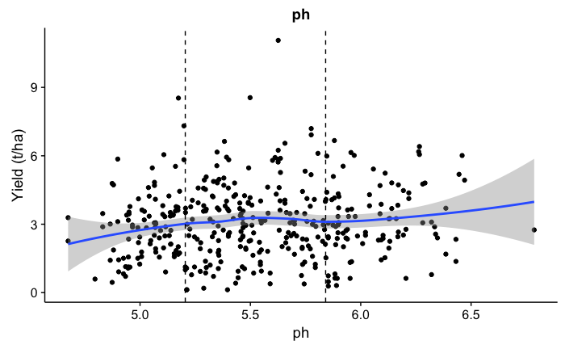

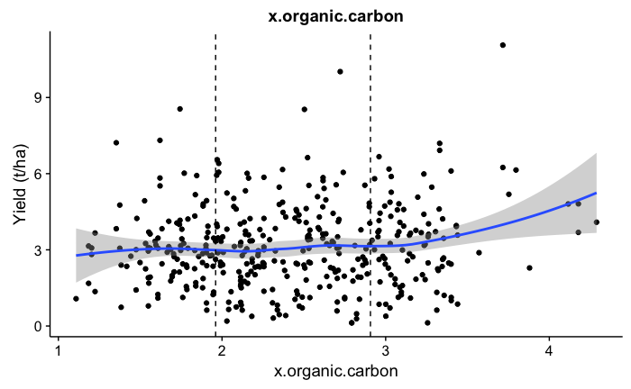

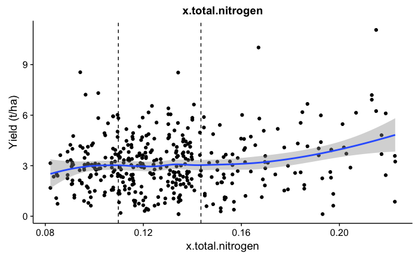

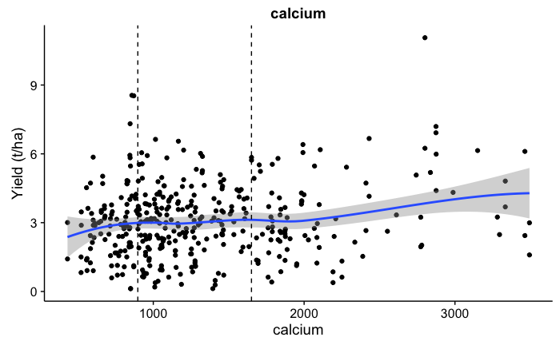

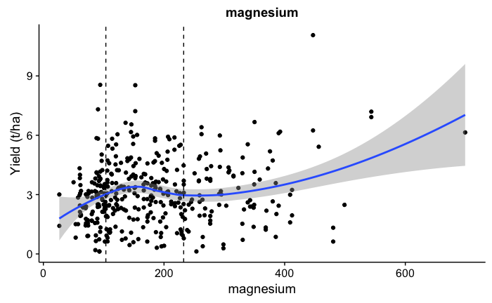

```r
for(i in 1:length(keySoilVars)){
  print(
  ggplot(py, aes(x = py[,keySoilVars[i]], y = tha)) +
    geom_point() +
    stat_smooth() +
    geom_vline(xintercept=summary(py[,keySoilVars[i]])[[2]], linetype="dashed") +
    geom_vline(xintercept=summary(py[,keySoilVars[i]])[[5]], linetype="dashed") +
    labs(title = keySoilVars[i], x= keySoilVars[i], y="Yield (t/ha)")
  )
}
```

```r
pdrFunction <- function(dat, var, outcome){
  powerVar = dat[,var]^2

  mod = lm(outcome ~ dat[,var] + powerVar, data=dat)

  if(summary(mod)$coeff[3]<0){
    beta1 <- summary(mod)$coeff[2]
    beta2 <- summary(mod)$coeff[3]
    keyPoint <- round((-beta1)/(2*beta2),2)
    tab = data.frame(var = var, result = keyPoint)
    return(tab)
  }else{
    return(data.frame(var = var, result= "NR"))
  }

}
```

## 4.1 All values

```r
indPdrTab <- do.call(rbind, lapply(keySoilVars, function(x){
  pdrFunction(py, x, py$tha)
}))
kable(indPdrTab, format="markdown")
```

| var | result |
| --- | --- |
| ph | 6.17 |
| x.organic.carbon | NR |
| x.total.nitrogen | NR |
| calcium | NR |
| magnesium | NR |

## 4.2 Site values

```r
py$site <- tolower(py$sublocation.x)
aggSite <- py %>%
  group_by(site) %>%
  summarize_each(funs(mean(., na.rm=T)), c(tha, ph, x.organic.carbon, x.total.nitrogen, calcium, magnesium)) %>%
  as.data.frame()
```

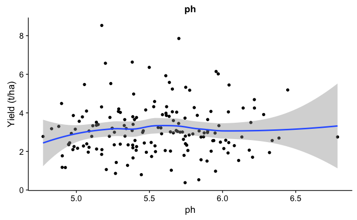

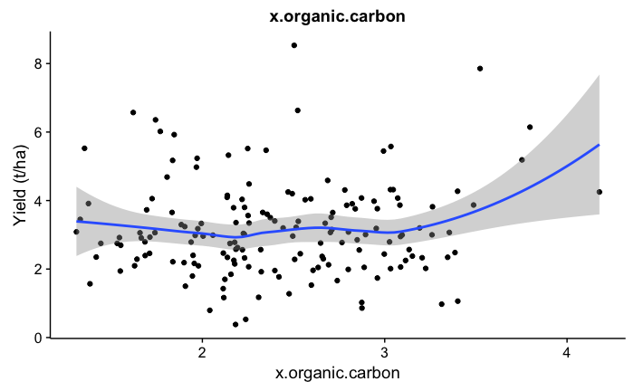

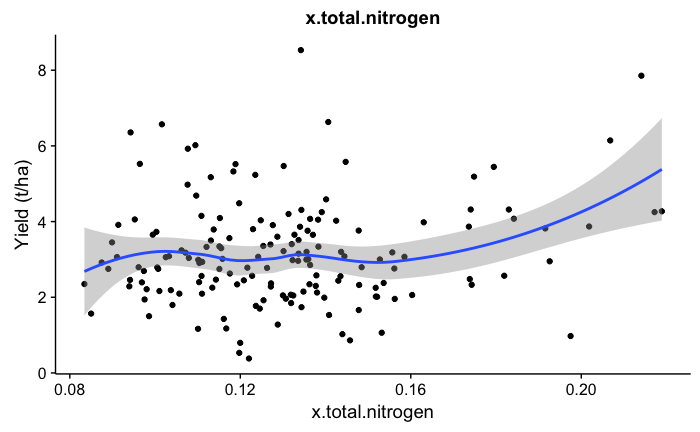

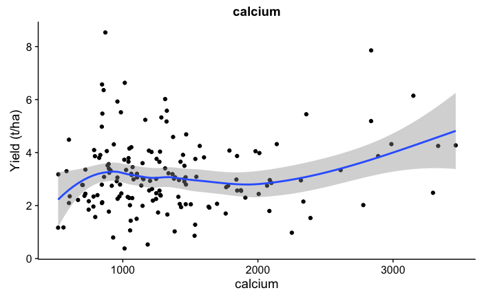

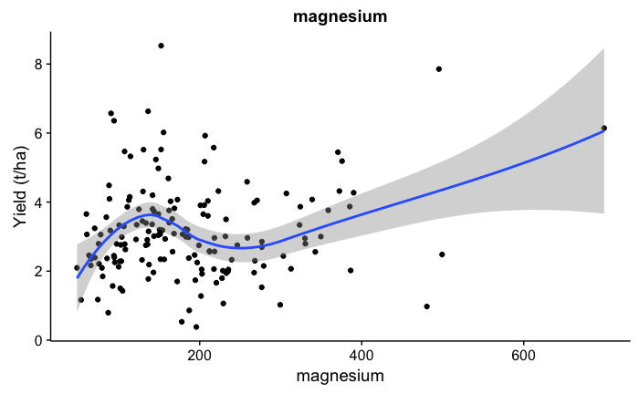

```r
for(i in 1:length(keySoilVars)){
  print(
  ggplot(aggSite, aes(x = aggSite[,keySoilVars[i]], y = tha)) +
    geom_point() +
    stat_smooth() +
    #stat_smooth(method="lm", color="red")+
    labs(title = keySoilVars[i], x= keySoilVars[i], y="Yield (t/ha)")
  )
}
```

The cell level results seem a bit more useable (??? big question mark). I’ll try to fit the expected relationship to these data and see where the coefficients cancel each other out

```r
aggTab <- do.call(rbind, lapply(keySoilVars, function(x){
  pdrFunction(aggSite, x, aggSite$tha)
}))
kable(aggTab, format="markdown")
```

| var | result |
| --- | --- |
| ph | 5.72 |
| x.organic.carbon | NR |
| x.total.nitrogen | NR |
| calcium | NR |
| magnesium | NR |

## 4.3 Wet chem

```r
pairedWetDir <- normalizePath(file.path("..", "..", "OAF Soil Lab Folder", "Projects", "ke_shs_maize_paired", "3_wet_chem"))
pairedWet <- read.csv(file=paste(pairedWetDir, "wet_chem.csv", sep = "/"))
pSoilIdDir <- normalizePath(file.path("..", "..", "OAF Soil Lab Folder", "Projects", "ke_shs_maize_paired", "5_merged"))
pSoilIds <- read_xlsx(paste(pSoilIdDir, "database.xlsx", sep = "/"), sheet=1) %>%
  as.data.frame()
pSoilIds <- pSoilIds %>%
  rename(ssn = plot_information.Bar_code) %>%
  mutate(
    ssn = gsub(" ", "", ssn),
    ssn = gsub("_", "", ssn)
  )
pairedWet <- pairedWet %>%
  mutate(
    Field_Name = tolower(Field_Name)
  ) %>%
  rename(ssn = Field_Name) %>%
  filter(ssn!="") %>%
  mutate(
    ssn = tolower(ssn),
    ssn = gsub("_", "", ssn)
  ) %>%
  left_join(., pSoilIds, by="ssn") %>%
  left_join(., py[,c("tha", "ssn")], by="ssn") %>%
  setNames(tolower(names(.)))
names(pairedWet) <- tolower(names(pairedWet))
```

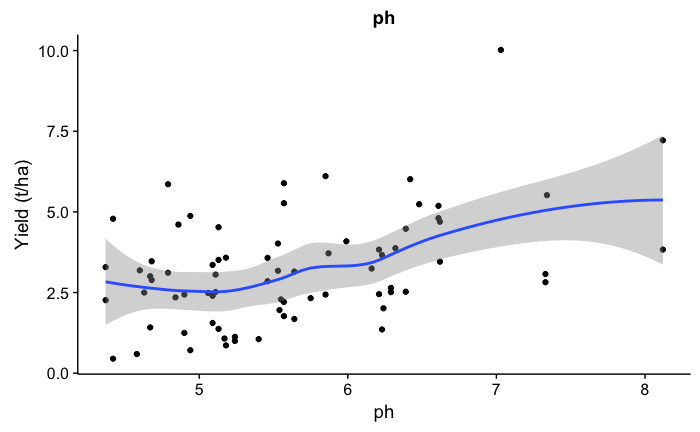

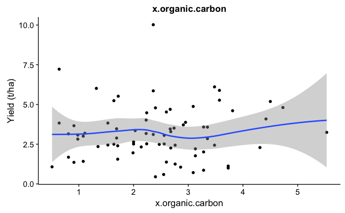

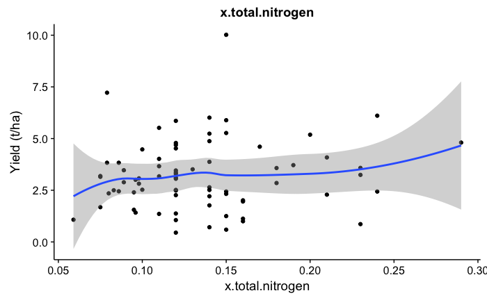

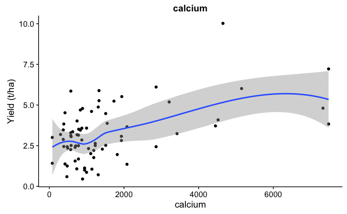

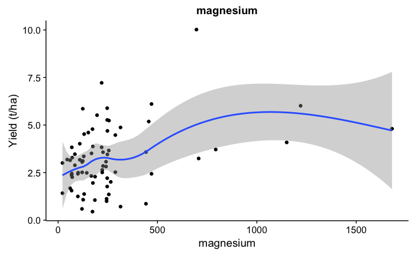

```r
for(i in 1:length(keySoilVars)){
  print(
  ggplot(pairedWet, aes(x = pairedWet[,keySoilVars[i]], y = tha)) +
    geom_point() +
    stat_smooth() +
    #stat_smooth(method="lm", color="red")+
    labs(title = keySoilVars[i], x= keySoilVars[i], y="Yield (t/ha)")
  )
}
```

Quick overview:

**Reminder**: the curves on these models is a loess curve. Loess takes a local average to derive a line of best fit. This line is by design very responsive to the data and not the model we’re using to detect the point of diminishing returns. It’s a good first check to see if it’s worth investigating.

```r
wetPdrTab <- do.call(rbind, lapply(keySoilVars, function(x){
  pdrFunction(pairedWet, x, pairedWet$tha)
}))
kable(wetPdrTab, format="markdown")
```

| var | result |
| --- | --- |
| ph | NR |
| x.organic.carbon | NR |
| x.total.nitrogen | NR |
| calcium | 7951.32 |
| magnesium | 1252.77 |

## 4.4 Summary

```r
sourceTab <- c("aggTab", "indPdrTab", "wetPdrTab")
pdrTab <- do.call(rbind, lapply(sourceTab, function(x){
  tab = get(x)
  return(data.frame(cbind(source = x, tab)))
  }))
kable(pdrTab, format="markdown")
```

| source | var | result |
| --- | --- | --- |
| aggTab | ph | 5.72 |
| aggTab | x.organic.carbon | NR |
| aggTab | x.total.nitrogen | NR |
| aggTab | calcium | NR |
| aggTab | magnesium | NR |
| indPdrTab | ph | 6.17 |
| indPdrTab | x.organic.carbon | NR |
| indPdrTab | x.total.nitrogen | NR |
| indPdrTab | calcium | NR |
| indPdrTab | magnesium | NR |
| wetPdrTab | ph | NR |
| wetPdrTab | x.organic.carbon | NR |
| wetPdrTab | x.total.nitrogen | NR |
| wetPdrTab | calcium | 7951.32 |
| wetPdrTab | magnesium | 1252.77 |

# 5 Soil Quartiles

Yield response table by quartile

```r
yQuartiles <- function(yVar, xVar, df){
  applyCuts = cut(df[,xVar], breaks=quantile(df[,xVar],c(0.25, 0.5, 0.75, 1),type=1, na.rm=T))
  tab = tapply(df[,yVar], applyCuts, function(x){mean(x, na.rm=T)})
  #diff = tab[[4]] - tab[[1]]
  return(tab)
}
yQChange <- function(tab, start, end){ #start and end are the indicies
  diff = tab[[end]]-tab[[start]]
  return(diff)
}
qTab <- do.call(rbind, lapply(keySoilVars, function(x){
  yQuartiles("tha", x, py)
}))
qTab <- as.data.frame(qTab)
names(qTab) <- c("q25to50","q50to75","q75to100")
qTab <- as.data.frame(sapply(qTab, function(x){round(x,2)}))
qTab <- cbind(qTab,
              diff25to50 = apply(qTab, 1, function(x){
                  yQChange(x,1,2)}),
              diff50to75 = apply(qTab, 1, function(x){
                  yQChange(x,2,3)}))
rownames(qTab) <- keySoilVars
```

```r
library(scales)
# add revenue
marketValueT <- 340
numFarmersKe <- 217000/4
qTab$revenueA <- dollar(qTab$diff25to50 * marketValueT)
qTab$revenueB <- dollar(qTab$diff50to75 * marketValueT)
write.csv(qTab, file="output/quartileCalc.csv")
```

## 5.1 Minimum Threshold

```r
pdf(file=paste("output", "carbon graph.pdf", sep="/"), width=11, height=8.5)
ggplot(py, aes(x=x.organic.carbon, y=tha)) +
  geom_point() +
  geom_vline(xintercept = summary(py$x.organic.carbon)[[2]]) +
  geom_vline(xintercept = summary(py$x.organic.carbon)[[5]]) +
  stat_smooth(method="lm") +
  labs(x = "Carbon", y = "Yield (t/ha)", title = "75% threshold looks weird because of farmers doing well at low C values",
       subtitle = "We can trim those values but then we're basically shaping the data to our story")
dev.off()
```